# Ex05_tasks

Xingyu.Hu

2022-10-21

1. The U.S. Department of Energy conducts weekly surveys of approximately 800 gasoline stations to determine the average price per gallon of regular gasoline. On December 10, 2012, the average price was $3.35 per gallon. Identify the population and the sample.
- **Population:** The price per gallon of regular gasoline of all of the gasoline stations in U.S. on December 10, 2012.
- **Sample:** The price per gallon of regular gasoline of the approximately 800 gasoline stations on December 10, 2012.
2. Simulate the Law of Large Numbers with the experiment of rolling a die (i.e. use the sample() function to simulate the experiment of rolling a die many times and calculate the probability of getting a certain side of the die.

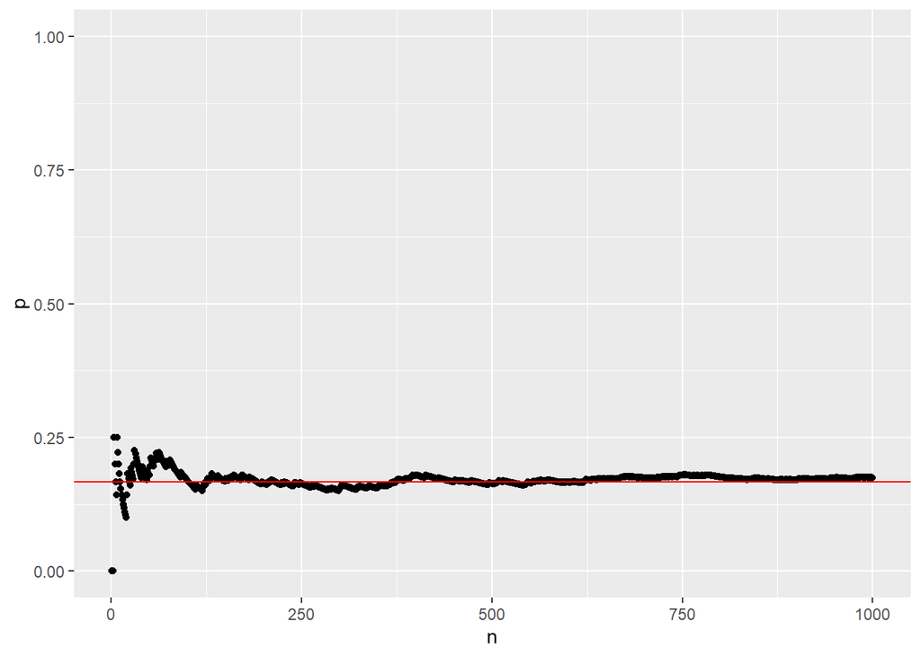

```r
p_die <- function(side, times = 100){
    library(ggplot2)
    x <- sample(1:6, times, replace = TRUE)
    y <- cumsum(x == side)
    e_die <- data.frame(n = 1:times, x, y)
    e_die$p <- e_die$y / e_die$n

    ggplot(e_die) +
        geom_point(aes(n, p)) +
        lims(y = c(0, 1)) +
        geom_hline(yintercept = 1 / 6, color = 'red')
}
p_die(side = 1, times = 1000)
```

```r
str(airquality)
```

```
## 'data.frame':    153 obs. of  6 variables:
##  $ Ozone  : int  41 36 12 18 NA 28 23 19 8 NA ...
##  $ Solar.R: int  190 118 149 313 NA NA 299 99 19 194 ...
##  $ Wind   : num  7.4 8 12.6 11.5 14.3 14.9 8.6 13.8 20.1 8.6 ...
##  $ Temp   : int  67 72 74 62 56 66 65 59 61 69 ...
##  $ Month  : int  5 5 5 5 5 5 5 5 5 5 ...
##  $ Day    : int  1 2 3 4 5 6 7 8 9 10 ...
```

```r
airquality$Month_English <- month.abb[airquality$Month]
head(airquality[, c("Month", "Month_English")])
```

```
##   Month Month_English
## 1     5           May
## 2     5           May
## 3     5           May
## 4     5           May
## 5     5           May
## 6     5           May
```

- **Month_English:** Nominal data
4. The ENV221 Students dataset was introduced in Lecture 2. Import it into R. This and the subsequent tasks will do some analysis based on this dataset.
1. Identify the type of each column in the dataset with nominal, ordinal, descrete, or continous data.

```r
stud <- read.csv("../Data/students_ENV221.csv")
str(stud)
```

```
## 'data.frame':    34 obs. of  10 variables:
##  $ ID    : int  1 2 3 4 5 6 7 8 9 10 ...
##  $ GENDER: chr  "Female" "Male" "Male" "Male" ...
##  $ YEAR  : int  2001 2022 2000 2002 2002 2000 2001 2002 2002 2001 ...
##  $ HEIGHT: int  165 183 170 176 170 172 175 175 153 177 ...
##  $ WEIGHT: int  54 75 115 70 65 60 72 60 NA 67 ...
##  $ SHOE  : num  38 44.5 41 44 39 42 42.5 39 36 42.5 ...
##  $ HOME  : chr  "North China" "South China" "North China" "North China" ...
##  $ MTH   : chr  "63" "NULL" "NULL" "NULL" ...
##  $ STAT  : chr  "2. I know a little about it." "2. I know a little about it." "2. I know a little about it." "3. I know some about it." ...
##  $ R     : chr  "1. I know nothing about it." "1. I know nothing about it." NA "1. I know nothing about it." ...
```

- **ID:** Nominal data
- **GENDER:** Nominal data
- **YEAR:** Descrete data
- **HEIGHT:** Continuous data
- **WEIGHT:** Continuous data
- **SHOE:** Descrete data
- **HOME:** Nominal data
- **MTH:** Descrete data
- **STAT:** Nominal data
- **R:** Nominal data
2. Add a new column ““R_level”“, showing the R level of each students with integers from 1 to 5. What is the data type of the new column?

```r
stud$R_level <- ifelse(stud$R == "1. I know nothing about it.", 1,
                       ifelse(stud$R == "2. I know a little about it.", 2,
                       ifelse(stud$R == "3. I know some about it.", 3,
                       ifelse(stud$R == "4. I know a lot about it.", 4, 5))))
head(stud[, c("R", "R_level")])
```

```
##                              R R_level
## 1  1. I know nothing about it.       1
## 2  1. I know nothing about it.       1
## 3                         <NA>      NA
## 4  1. I know nothing about it.       1
## 5  1. I know nothing about it.       1
## 6 2. I know a little about it.       2
```

- **R_level:** Ordinal data